# Productivity and competition

Stefan Hartmann

2023-11-19

This document contains the code used to produce the productivity analyses in Kristian Berg’s and my contribution to the Oxford Handbook of Historical Morphology. The analyses mainly serve illustrative purposes, which is why we use data that would require much more careful manual correction for a serious analysis.

## Preliminaries

```r
# load packages

library(tidyverse)
library(patchwork)
library(zipfR)
```

## Data collection and data wrangling

We used the [CLMET](https://fedora.clarin-d.uni-saarland.de/clmet/clmet.html) corpus, searching it via the [Corpus Workbench](https://cwb.sourceforge.io/) using the following query:

```r
cwb-scan-corpus CLMET lemma text_period >  "clmet_lemma_period.txt"
```

The data is then read into R and slightly modified:

```r
# read data: full CLMET frequency list
d <- read_delim("clmet_lemma_period.txt", delim = "\t", quote = "",
                col_names = c("Freq", "lemma", "period"))

# omit punctuation:
# we replace all instances where the string consísts only
# of punctuation
d <- d[-grep("^[[:punct:]]+", d$lemma),]
```

## Analyses

To apply the classic productivity measures, we first need to identify the types and tokens, as well as the hapax legomena, i.e. the words only attested once in the corpus.

```r
# frequency list per period
d_tbl <- d %>% group_by(lemma, period) %>% summarise(
  n = sum(Freq)
)


# frequency list for the entire corpus
d_tbl2 <- d %>% group_by(lemma) %>% summarise(
  n_all = sum(Freq)
)

# combine both tables
d_tbl <- left_join(d_tbl, d_tbl2)

# add hapax column
d_tbl <- mutate(d_tbl, hapax = ifelse(n_all == 1, TRUE, FALSE))
```

## Classic productivity measures

Using these data, we can plot the classic productivity measures.

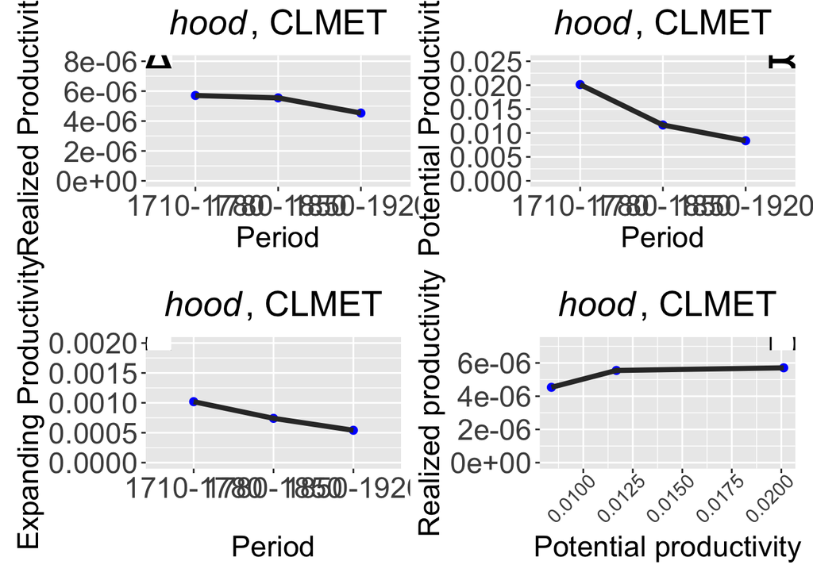

```r
# find tokens ending in -hood
d_tbl <- mutate(as.data.frame(d_tbl), hood = grepl(".+hood", d_tbl$lemma))

# calculate potential, realized, and expanding productivity
productivity <- d_tbl %>% group_by(period) %>% summarise(
  types_hood = length(which(hood==TRUE)),
  types_all = n(),
  tokens_hood = sum(n[hood == TRUE]),
  tokens_all = sum(n),
  hapaxes_hood = length(which(hood == TRUE & hapax == TRUE)),
  hapaxes_all = length(which(hapax == TRUE)),
  pot_prod = hapaxes_hood / tokens_hood,
  real_prod = types_hood / tokens_all,
  expand_prod = hapaxes_hood / hapaxes_all
)


# plot productivity

# potential
p1 <- ggplot(productivity, aes(x = period, y = pot_prod, group = 1)) +
  geom_point(size=2, col = "blue") + geom_line(lwd = 1.5, col = "grey20") + ylab("Potential Productivity") +
  xlab("Period") + ggtitle(expression(paste(italic("hood"), ", CLMET"))) +
  theme(plot.title = element_text(face = "bold", hjust = 0.5)) +
  theme(axis.text = element_text(size = 18)) +
  theme(axis.title = element_text(size = 18)) +
  theme(strip.text = element_text(size = 18)) +
  theme(legend.text = element_text(size = 18)) +
  theme(legend.title = element_text(size = 18, face = "bold")) +
  theme(text = element_text(size = 18)) +
  theme(plot.margin = margin(0,0,18,0)) + ylim(c(0,0.025))

# realized
p2 <- ggplot(productivity, aes(x = period, y = real_prod, group = 1)) +
  geom_point(size=2, col = "blue") + geom_line(lwd = 1.5, col = "grey20") + ylab("Realized Productivity") +
  xlab("Period") + ggtitle(expression(paste(italic("hood"), ", CLMET"))) +
  theme(plot.title = element_text(face = "bold", hjust = 0.5)) +
  theme(axis.text = element_text(size = 18)) +
  theme(axis.title = element_text(size = 18)) +
  theme(strip.text = element_text(size = 18)) +
  theme(legend.text = element_text(size = 18)) +
  theme(legend.title = element_text(size = 18, face = "bold")) +
  theme(text = element_text(size = 18)) +
    theme(plot.margin = margin(0,5,18,0)) + ylim(c(0,8e-06))

# expanding
p3 <- ggplot(productivity, aes(x = period, y = expand_prod, group = 1)) +
  geom_point(size=2, col = "blue") + geom_line(lwd=1.5, col = "grey20") + ylab("Expanding Productivity") +
  xlab("Period") + ggtitle(expression(paste(italic("hood"), ", CLMET"))) +
  theme(plot.title = element_text(face = "bold", hjust = 0.5)) +
  theme(axis.text = element_text(size = 18)) +
  theme(axis.title = element_text(size = 18)) +
  theme(strip.text = element_text(size = 18)) +
  theme(legend.text = element_text(size = 18)) +
  theme(legend.title = element_text(size = 18, face = "bold")) +
  theme(text = element_text(size = 18)) + ylim(c(0,2e-03))

# global
p4 <- ggplot(productivity, aes(x = pot_prod, y = real_prod, group = 1)) +
  geom_point(size=2, col = "blue") + geom_line(lwd=1.5, col = "grey20") + ylab("Realized productivity") +
  xlab("Potential productivity") + ggtitle(expression(paste(italic("hood"), ", CLMET"))) +
  theme(plot.title = element_text(face = "bold", hjust = 0.5)) +
  theme(axis.text = element_text(size = 18)) +
  theme(axis.title = element_text(size = 18)) +
  theme(strip.text = element_text(size = 18)) +
  theme(legend.text = element_text(size = 18)) +
  theme(legend.title = element_text(size = 18, face = "bold")) +
  theme(text = element_text(size = 18)) +
  theme(axis.text.x = element_text(angle=45, hjust=.9, size=12)) +
    ylim(c(0, 7.2e-06))

# insets for "numbering" the plots:

# helper tibble:
x <- tibble(a = 1,
            b = 1)

# "plots" with labels:
p1a <- ggplot(x, aes(x = a, y = b, label = "A")) + geom_text(size = 12) +
  theme_void() + theme(panel.background = element_rect(fill = "white", color = "white"))
p1b <- ggplot(x, aes(x = a, y = b, label = "B")) + geom_text(size = 12) +
  theme_void() + theme(panel.background = element_rect(fill = "white", color = "white"))
p1c <- ggplot(x, aes(x = a, y = b, label = "C")) + geom_text(size = 12) +
  theme_void() + theme(panel.background = element_rect(fill = "white", color = "white"))
p1d <- ggplot(x, aes(x = a, y = b, label = "D")) + geom_text(size = 12) +
  theme_void() + theme(panel.background = element_rect(fill = "white", color = "white"))


# 2x2 array:
(p2 + inset_element(p1a, left = 0, bottom = 0.9, right = .1, top = 1) |
    p1 + inset_element(p1b, left = 1, bottom = 0.9, right = 0.9, top = 1) ) /
(p3 + inset_element(p1c, left = 0, bottom = 0.9, right = .1, top = 1) |
   p4 + inset_element(p1d, left = 1, bottom = 0.9, right = 0.9, top = 1) )
```

## Zipf-Mandelbrot model

Next, we use Zipf-Mandelbrot extrapolation to get a more fine-grained picture of the pattern’s productivity. For this purpose, we first need to generate the spc files required by the zipfR package.

```r
# frequency spectra - spc files

# period 1
filter(d, period == levels(factor(d$period))[1])$Freq %>%
  table %>%
  as_tibble() %>%
  setNames(c("m", "Vm")) %>% write.table("clmet_hood_period01.spc", row.names=F, quote=F, sep="\t")

# period 2
filter(d, period == levels(factor(d$period))[2])$Freq %>%
  table %>%
  as_tibble() %>%
  setNames(c("m", "Vm")) %>% write.table("clmet_hood_period02.spc", row.names=F, quote=F, sep="\t")

# period 3
filter(d, period == levels(factor(d$period))[3])$Freq %>%
  table %>%
  as_tibble() %>%
  setNames(c("m", "Vm")) %>% write.table("clmet_hood_period03.spc", row.names=F, quote=F, sep="\t")
```

Using the spc files, we can fit the Zipf-Mandelbrot model, and plot the results.

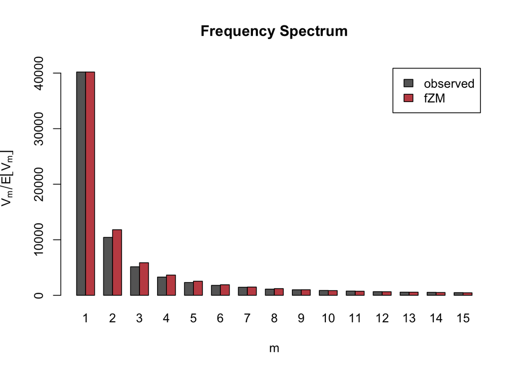

```r
# read spc files
hood_spc01 <- read.spc("clmet_hood_period01.spc")
hood_spc02 <- read.spc("clmet_hood_period02.spc")
hood_spc03 <- read.spc("clmet_hood_period03.spc")

# Zipf-Mandelbrot model
fzm01 <- lnre("fzm", hood_spc01, m.max=1)
fzm02 <- lnre("fzm", hood_spc02, m.max=1)
fzm03 <- lnre("fzm", hood_spc03, m.max=1)

# lnre.spc
fzm.spc01 <-  lnre.spc(fzm01, N(fzm01))
fzm.spc02 <-  lnre.spc(fzm02, N(fzm02))
fzm.spc03 <-  lnre.spc(fzm03, N(fzm03))

# plot
plot(hood_spc01, fzm.spc01, legend = c("observed", "fZM"))
```

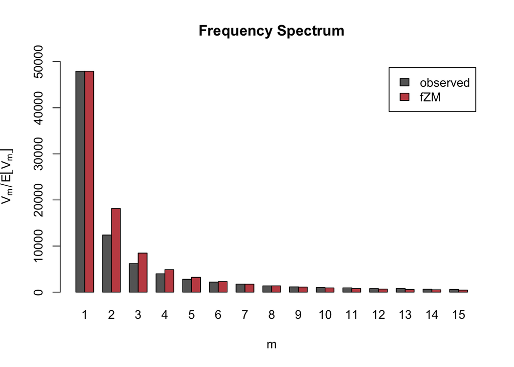

```r
plot(hood_spc02, fzm.spc02, legend = c("observed", "fZM"))
```

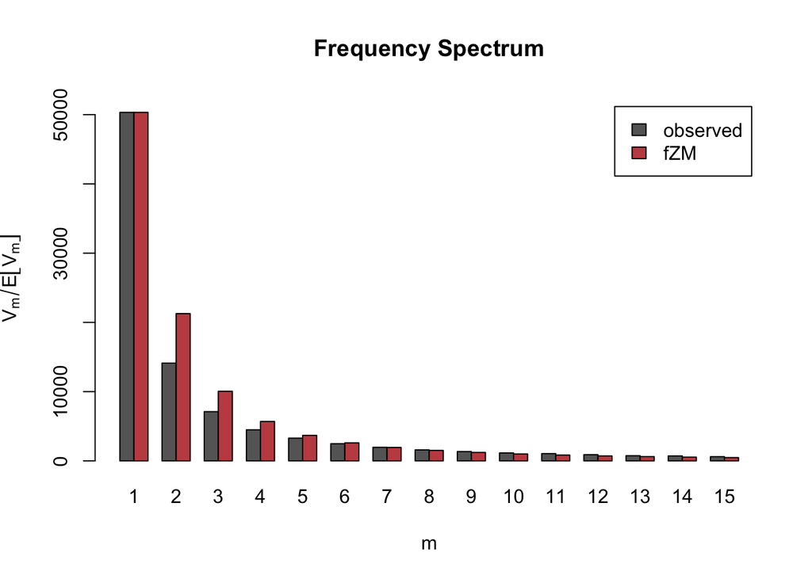

```r
plot(hood_spc03, fzm.spc03, legend = c("observed", "fZM"))
```

Also, we can assess the model’s goodness of fit (spoiler alert: it’s rather bad; but again, we’re only doing this for expository purposes anyway).

```r
# goodness of fit:
summary(fzm01)
```

```
## finite Zipf-Mandelbrot LNRE model.
## Parameters:
##    Shape:          alpha = 0.513262
##    Lower cutoff:       A = 2.093213e-09
##    Upper cutoff:       B = 0.004569823
##  [ Normalization:      C = 6.709159 ]
## Population size: S = 372205.9
## Sampling method: Poisson, with exact calculations.
##
## Parameters estimated from sample of size N = 10334844:
##                     V       V1       V2      V3      V4      V5
##    Observed: 86077.00 40196.00 10429.00 5135.00 3286.00 2311.00 ...
##    Expected: 86076.95 40195.97 11805.74 5865.27 3646.43 2542.83 ...
##
## Goodness-of-fit (multivariate chi-squared test):
##          X2 df p
##    15820.47 13 0
```

```r
summary(fzm02)
```

```
## finite Zipf-Mandelbrot LNRE model.
## Parameters:
##    Shape:          alpha = 0.7102935
##    Lower cutoff:       A = 1.604575e-08
##    Upper cutoff:       B = 0.2528344
##  [ Normalization:      C = 0.4350557 ]
## Population size: S = 210661.9
## Sampling method: Poisson, with exact calculations.
##
## Parameters estimated from sample of size N = 11171523:
##                     V       V1       V2      V3      V4     V5
##    Observed: 102049.0 47930.00 12395.00 6193.00 3975.00 2793.0 ...
##    Expected: 102048.9 47929.91 18153.17 8473.93 4880.72 3212.3 ...
##
## Goodness-of-fit (multivariate chi-squared test):
##          X2 df p
##    154482.5 13 0
```

```r
summary(fzm03)
```

```
## finite Zipf-Mandelbrot LNRE model.
## Parameters:
##    Shape:          alpha = 0.7686411
##    Lower cutoff:       A = 2.048147e-08
##    Upper cutoff:       B = 2.42527
##  [ Normalization:      C = 0.1910716 ]
## Population size: S = 201965.2
## Sampling method: Poisson, with exact calculations.
##
## Parameters estimated from sample of size N = 12569027:
##                   V       V1       V2       V3      V4     V5
##    Observed: 111317 50329.00 14119.00  7110.00 4489.00 3284.0 ...
##    Expected: 111317 50328.98 21268.59 10055.24 5694.52 3684.6 ...
##
## Goodness-of-fit (multivariate chi-squared test):
##          X2 df p
##    216725.5 13 0
```

Most importantly, we can extrapolate vocabulary and hapax growth curves and plot them.

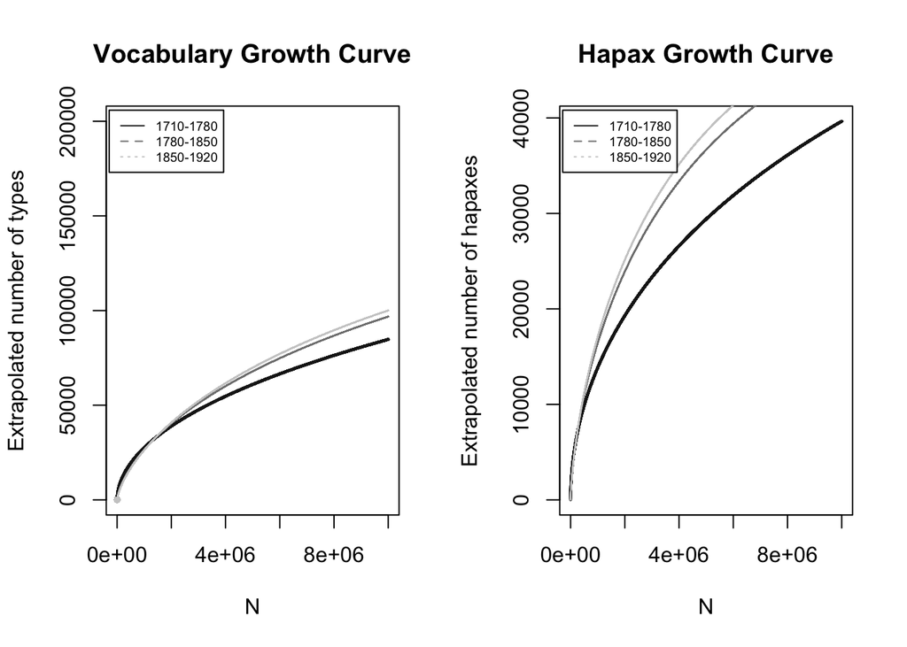

```r
# extrapolated vocbulary growth curves
period01.vgc <- lnre.vgc(fzm01, 1:1e07, m.max = 1)
period02.vgc <- lnre.vgc(fzm02, 1:1e07, m.max = 1)
period03.vgc <- lnre.vgc(fzm03, 1:1e07, m.max = 1)


# get empirical vocabulary growth
p01 <- readLines("clmet_hood_period01.txt")
p01 <- gsub(".*<|>", "", p01)

p02 <- readLines("clmet_hood_period02.txt")
p02 <- gsub(".*<|>", "", p02)

p03 <- readLines("clmet_hood_period03.txt")
p03 <- gsub(".*<|>", "", p03)


# modified function for getting emp.vgc

emp.vgc <- function(x) {
  seqs <- seq(0, length(x), 100)
  seqs <- seqs[2:length(seqs)]

  for(i in 1:length(seqs)) {
    x_tbl <- x[1:seqs[i]] %>% table %>% as_tibble() %>% setNames(c("lemma", "n"))

    cur <- tibble(
      N = seqs[i],
      V = nrow(x_tbl),
      V1 = length(which(x_tbl$n==1))
    )

    if(i == 1) {
      emp.vgc <- cur
    } else {
      emp.vgc <- rbind(emp.vgc, cur)
    }




  }

  return(emp.vgc)

}


# emp.pgc for each period
period01.emp.vgc <- emp.vgc(p01)
period02.emp.vgc <- emp.vgc(p02)
period03.emp.vgc <- emp.vgc(p03)

# plot vocabulary growth curve
par(mfrow = c(1,2))
plot(period01.vgc$N, period01.vgc$V, type="l", lty = 1, col="grey10",
     lwd=2, main="Vocabulary Growth Curve",
     ylab="Extrapolated number of types", xlab="N", ylim = c(0,2e05))
points(period01.emp.vgc$N, period01.emp.vgc$V1, pch=10, col="grey10",
       cex=0.5)
lines(period02.vgc$N, period02.vgc$V, type="l", col="grey50", lty=2)
points(period02.emp.vgc$N, period02.emp.vgc$V1, pch=10, col="grey50", cex=0.5)
lines(period03.vgc$N, period03.vgc$V, type="l", col="grey80", lty=3)
points(period03.emp.vgc$N, period03.emp.vgc$V1, pch=10, col="grey80", cex=0.5)
legend("topleft",
       inset=c(0.01,0.01),
       lty=c(1,2,3),
       col=c("grey10", "grey50", "grey80"),
       legend=c(levels(factor(d$period))[1],
                levels(factor(d$period))[2],
                levels(factor(d$period))[3]), cex=0.6)

# plot hapax growth curve
plot(period01.vgc$N, period01.vgc$V1, type="l", col="grey10",
     lwd=2, main="Hapax Growth Curve",
     ylab="Extrapolated number of hapaxes", xlab="N")
lines(period02.vgc$N, period02.vgc$V1, type="l", col="grey50", lty=2)
lines(period03.vgc$N, period03.vgc$V1, type="l", col="grey80", lty=3)

legend("topleft",
       inset=c(0.01,0.01),
       lty=c(1,2,3),
       col=c("grey10", "grey50", "grey80"),
       legend=c(levels(factor(d$period))[1],
                levels(factor(d$period))[2],
                levels(factor(d$period))[3]), cex=0.6)
```

```r
par(mfrow = c(1,1))
```

## Bootstrapping approach

Finally, we use Säily’s bootstrapping approach to take a closer look at the pattern’s productivity. For doing so, we first create containers that are then filled with types from randomly shuffled texts.

```r
# container for results
container1 <- list()
container2 <- list()
container3 <- list()

# seqs based on the smallest time period
seqs <- seq(0, 468975, 10000)

# set seed
set.seed(1985)

for(i in 1:5000) {
  # randomly shuffle texts
  d$text <- factor(d$text, levels = sample(unique(d$text), length(unique(d$text))))
  d <- d %>% arrange(text)

  d1 <- filter(d, Period == "1710-1780")
  d2 <- filter(d, Period == "1780-1850")
  d3 <- filter(d, Period == "1850-1920")

  # add duplicate column so that only first instances
  # (types) are considered
  d1$duplicated <- duplicated(d1$Lemma)
  d2$duplicated <- duplicated(d2$Lemma)
  d3$duplicated <- duplicated(d3$Lemma)

  # add column with counter
  d1$counter <- NA
  d1[which(d1$duplicated == FALSE & d1$hood == TRUE),]$counter <- 1:nrow(d1[which(d1$duplicated == FALSE & d1$hood == TRUE),])
  d1 <- fill(d1, counter) # fill downwards
  container1[[i]] <- d1[seqs,]$counter

  d2$counter <- NA
  d2[which(d2$duplicated == FALSE & d2$hood == TRUE),]$counter <- 1:nrow(d2[which(d2$duplicated == FALSE & d2$hood == TRUE),])
  d2 <- fill(d2, counter) # fill downwards
  container2[[i]] <- d2[seqs,]$counter

  d3$counter <- NA
  d3[which(d3$duplicated == FALSE & d3$hood == TRUE),]$counter <- 1:nrow(d3[which(d3$duplicated == FALSE & d3$hood == TRUE),])
  d3 <- fill(d3, counter) # fill downwards
  container3[[i]] <- d3[seqs,]$counter

  print(i)
}

# export bootstrapping results
write_rds(container1, "container1.Rds")
write_rds(container2, "container2.Rds")
write_rds(container3, "container3.Rds")
```

```r
# read in bootstrapping results
container1 <- read_rds("container1.Rds")
container2 <- read_rds("container2.Rds")
container3 <- read_rds("container3.Rds")
```

Now we can plot the results.

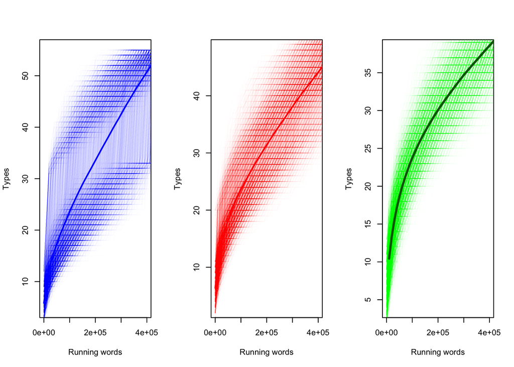

```r
par(mfrow = c(1,3))
plot(seqs[1:length(container1[[1]])], container1[[1]], type = "n",
     ylab = "Types", xlab = "Running words", xlim = c(0,4e05))
invisible(sapply(1:length(container1), function(i)
  lines(seqs[1:length(container1[[1]])],
        container1[[i]],
        col = rgb(red = 0, blue = 1, green = 0, alpha = .009))))
lines(seqs[1:length(container1[[1]])],
      sapply(1:length(container1[[1]]),
             function(j) mean(sapply(1:length(container1),
                                     function(i) container1[[i]][j]))),
      col = "blue", lwd = 2)
title(levels(factor(d$Period))[1])

plot(seqs[1:length(container2[[1]])], container2[[1]], type = "n",
     ylab = "Types", xlab = "Running words", xlim = c(0,4e05))
invisible(sapply(1:length(container2), function(i)
  lines(seqs[1:length(container2[[1]])], container2[[i]],
        col = rgb(red = 1, blue = 0, green = 0, alpha = .009))))
lines(seqs[1:length(container2[[1]])],
      sapply(1:length(container2[[1]]),
             function(j) mean(sapply(1:length(container2),
                                     function(i) container2[[i]][j]))),
      col = "red", lwd = 2)
title(levels(factor(d$Period))[2])

plot(seqs[1:length(container3[[1]])], container3[[1]], type = "n",
     ylab = "Types", xlab = "Running words", xlim = c(0,4e05))
invisible(sapply(1:length(container3), function(i)
  lines(seqs[1:length(container3[[1]])], container3[[i]],
        col = rgb(red = 0, blue = 0, green = 1, alpha = .009))))
lines(seqs[1:length(container3[[1]])],
      sapply(1:length(container3[[1]]),
             function(j) mean(sapply(1:length(container3),
                                     function(i) container3[[i]][j]))),
      col = "darkgreen", lwd = 3)
title(levels(factor(d$Period))[3])
```

```r
par(mfrow = c(1,1))
```